# Lecture 27 - Into Deep Learning P3

This is an [R Markdown](http://rmarkdown.rstudio.com) Notebook

### Lecture 27 - Your project. Deep Learning with H2O. P.2 Implement Deep Learning Model to ShinyApp

Deep Learning… This lecture is dedicated to the implementation of Deep Learning models into for our Data

#### Work overview (from previous lectures)

- re-arranging data as matrix - DONE
- fitting deep learning models - DONE
- testing the models - DONE
- saving models - DONE
- use model to make predictions and create meaningful ouputs
- implementation in our ShinyApp…

In order to achieve this goal we will have to perform some steps:

1. Learn how to use saved model in R to make predictions
2. Develop and app usage strategy graphical output
3. Return to our time series to identify time of anomaly
4. ‘Pack’ our code to functions
5. Add Tab for Anomaly Detection with Shiny

#### Using saved h2o model in R

One of the Goals of this lecture will be to see how to use this model in R to make predictions

From: (R h2o load a saved model from disk in MOJO or POJO format)[https://stackoverflow.com/questions/45335697/r-h2o-load-a-saved-model-from-disk-in-mojo-or-pojo-format]

We know that two types of strategy are possible

1. use a binary model
2. export a model to MOJO (or POJO) form

#### Using Binary Model to make predictions

We will first use the first option to actually keep H2O on the background to make predictions

```r
library(h2o)
library(tidyverse)
library(plotly)
```

Initializing H2O and loading the model

```r
# initialize h2o
h2o.init()
```

```
H2O is not running yet, starting it now...

Note:  In case of errors look at the following log files:
    C:\Users\fxtrams\AppData\Local\Temp\RtmpUHSa1V/h2o_fxtrams_started_from_r.out
    C:\Users\fxtrams\AppData\Local\Temp\RtmpUHSa1V/h2o_fxtrams_started_from_r.err

java version "1.8.0_121"
Java(TM) SE Runtime Environment (build 1.8.0_121-b13)
Java HotSpot(TM) 64-Bit Server VM (build 25.121-b13, mixed mode)

Starting H2O JVM and connecting: . Connection successful!

R is connected to the H2O cluster:
    H2O cluster uptime:         2 seconds 828 milliseconds
    H2O cluster version:        3.14.0.7
    H2O cluster version age:    27 days
    H2O cluster name:           H2O_started_from_R_fxtrams_whc645
    H2O cluster total nodes:    1
    H2O cluster total memory:   1.77 GB
    H2O cluster total cores:    4
    H2O cluster allowed cores:  4
    H2O cluster healthy:        TRUE
    H2O Connection ip:          localhost
    H2O Connection port:        54321
    H2O Connection proxy:       NA
    H2O Internal Security:      FALSE
    H2O API Extensions:         Algos, AutoML, Core V3, Core V4
    R Version:                  R version 3.2.5 (2016-04-14)
```

```r
# load model
normality_model <- h2o.loadModel("www/tmp/normality_model.bin/DeepLearning_model_R_1510597411656_1")
```

#### Datasets needed for predictions

We will also need to quickly construct the dataset we can predict the result

```r
# ============= READ DATA =================
# Read our small data ...
DF_Data_Recent <- readRDS("DF_Data_Process_Recent.data")
DF_Equipm <- read_csv("DF_EquipmData.csv")
# data frame containing Event Names
DF_EvCode <- read_csv("DF_EvCodeDataProject.csv")
# Data manipulation and saving to the DF_TEMP
DF_TEMP <- DF_Data_Recent %>%
  # join to decode equipment serial number
  inner_join(DF_Equipm, by = "IDEquipment") %>%
  # join to decode Event Code meaning
  inner_join(DF_EvCode, by = "EventCode") %>%
  # select only column needed
  select(StartDate, Name, AnalogVal, EventText)
remove(DF_Data_Recent, DF_Equipm, DF_EvCode)
```

Will be using Machine #4 for that

```r
# importing R function from file
source("to_matrix.R")
DF_M4 <- DF_TEMP %>%
  to_matrix(filter_Event = "Tubing Process, resistance Ohm",
            filter_Machine = "Machine #4",n_cols = 150)
```

#### Catching corresponding dates & time

To extract the time… I have modified our function that extracts `AnalogVal` variable and saved that to the R script `to_matrixDT.R`

```r
# importing R function from file
source("to_matrixDT.R")
```

Let’s use this function to extract corresponding Date and Time…

```r
# prepared matrix containing date and time elements
DF_M4DT <- to_matrixDT(DF_TEMP,
                   filter_Event = "Tubing Process, resistance Ohm",
                   filter_Machine = "Machine #4",
                   n_cols = 150)
```

#### Detecting anomaly on Machine 4

In order to use data on `DF_M4` dataset we need to make it H2OFrame class. We need to load this object into H2O environment

```r
# load dataset into H2O environment
test_M4  <- as.h2o(x = DF_M4, destination_frame = "test_M4")
```

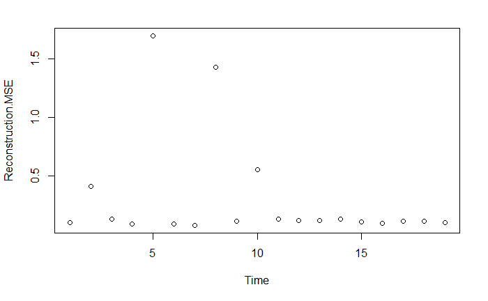

```r
# use MSE output to detect the anomalies
h2o.anomaly(normality_model, test_M4) %>% as.data.frame() %>% plot.ts(type = "p")
```

#### Anomaly detection: GUI strategy

Once we are capable to detect anomaly, if any, we need to define the way we should ‘surprise’ our users with our predictions. There are probably several ways to do this:

A. Split results by groups on a condition: GOOD/BAD or PASS/FAIL, etc B. Output ‘Analogue’ value or ‘Rating’ C. Use both or combination

For the example of the course I would be using variant B - Output ‘AnomalyRating’ value or all observations. Additionally I would still keep the optional part A where we can ‘cutoff’ the observations to split classes

#### A Split the results by groups

We will save prediction to the dataframe first:

```r
# save MSE values
mse_out <- h2o.anomaly(normality_model, test_M4) %>% as.data.frame()
```

This brings us to the point of create a ‘cutoff’ which I will set as 0.25. MSE values scored above this value will be identifyed as anomaly.

```r
# filter anomalies
rows_anomals <- which(mse_out > 0.25)
rows_normals <- which(mse_out <= 0.25)
```

Using these rows we can subset our anomalous observations

```r
# subset rows with matrices that shows the anomalies
matr_anomals <- DF_M4[rows_anomals, ]
# subset rows with matrices that does not show the anomalies
matr_normals <- DF_M4[rows_normals, ]
```

Just out of curiosity I will plot the anomalies values as 3D plot

```r
plot_ly(z = matr_anomals, type = "surface")
```

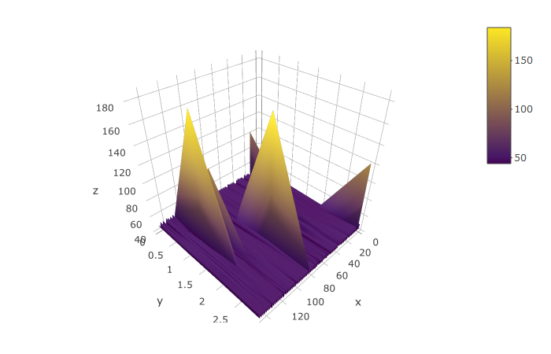

Extracted observations with anomaly

This is wonderful! High anomalous spikes were detected!

And also those without

```r
plot_ly(z = matr_normals, type = "surface")
```

There is no spikes!

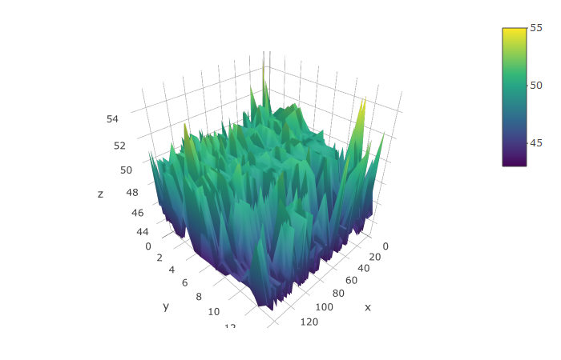

Data points without anomaly

#### Merge the MSE and values to interpret as anomaly level

Goal of further data manipulations will be to get back both columns Date/Time and Analog Value and add one new column with Model MSE output. This will be less cumbersome and will give operators of the process possibility to have more clear understanding for interpretation of the process

|  | StartDate | AnalogVal | AnomalyRating |
| --- | --- | --- | --- |
| 1 | 2017-09-03 17:44:53 | 45 | 0.107516 |
| 2 | 2017-09-03 17:49:53 | 45 | 0.107516 |
| 3 | 2017-09-03 17:54:07 | 53 | 0.107516 |
| 4 | 2017-09-03 17:54:13 | 46 | 0.107516 |
| 5 | 2017-09-03 17:54:53 | 46 | 0.107516 |
| 6 | 2017-09-03 17:59:53 | 46 | 0.107516 |

#### Visualize the result

Will be using a color pallet to output the result as a continous scale

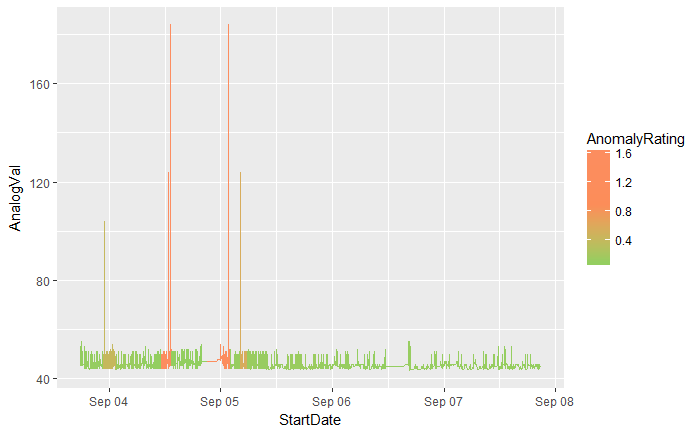

```r
library(RColorBrewer)
#http://colorbrewer.org
myspecial <- c("#91cf60", "#fc8d59", "#fc8d60")
ggplot(DF_F, aes(x = StartDate, y = AnalogVal, colour = AnomalyRating)) + geom_line() + scale_colour_gradientn(colours=myspecial)
```

#### Generalize function

Before we move to the implementation in Shiny it would be necessary to have generalized function just to have this job of data transformation

```r
# function from_matrix
# PURPOSE: output original time-series dataframe with attached column for Mean Square Error of the model
# USAGE: function will replicate the MSE error result and parse it back to corresponding rows of matrix
#        then it will convert matrix to vectors and construct the dataframe
from_matrix <- function(x_mse, x_Val, x_DT) {
  # x_mse - dataframe with model scoring results
  # x_Val - original matrix with Analog values
  # x_DT  - original matrix with corresponding Date Time values
  #x_Val <- DF_M4
  #x_DT  <- DF_M4DT
  # find the number of rows to replicate
  n_cols <- dim(x_Val)[2]
  # check for dimension of supplied matrixes
    # Add stopifnot() to check dimensions of both matrixes
    stopifnot(dim(x_Val) == dim(x_DT))
  # mse_out is a dataframe containing MSE error for each row of the matrix, we replicate this... 150 times...
  DF_M4mse <- do.call(cbind, replicate(n_cols, as.matrix(x_mse), simplify=FALSE))

  # going to combine this result with our objects DF_M4 and DF_M4DT
  DF_V <- x_Val %>% t() %>% c() %>% as.data.frame()
  colnames(DF_V) <- "AnalogVal"
  DF_T <- x_DT %>% t() %>% c() %>% as.POSIXct() %>%  as.data.frame()
  colnames(DF_T) <- "StartDate"
  DF_A <- DF_M4mse %>% t() %>% c() %>% as.data.frame()
  colnames(DF_A) <- "AnomalyRating"

  # return final dataframe:
  DF_F <- DF_V %>% bind_cols(DF_T, DF_A)
  return(DF_F)
}
```

Try this out:

```r
# using a function to return dataframe
DF_M4_Ready <- from_matrix(mse_out, DF_M4, DF_M4DT)
```

#### Time to Shiny?

Yes in the next lecture we will look into implementation of this code in Shiny!

And let’s not forget to switch off our cluster!

```r
h2o.shutdown(prompt= FALSE)
```

```
[1] TRUE
```

#### Conclusion

Below are the things we did in this lecture:

1. Learn how to use saved model in R to make predictions
2. Develop and app usage strategy graphical output
3. Return to our time series to identify time of anomaly
4. ‘Pack’ our code to functions

With that we are now ready to implement our Anomaly Detection with Deep Learning in ShinyApp

#### used references

example from: (https://dzone.com/articles/anomaly-detection-with-deep-learning-in-r-with-h2o)[https://dzone.com/articles/anomaly-detection-with-deep-learning-in-r-with-h2o]

More reading: (https://dzone.com/articles/the-basics-of-deep-learning-how-to-apply-it-to-pre?fromrel=true)[https://dzone.com/articles/the-basics-of-deep-learning-how-to-apply-it-to-pre?fromrel=true]

The phylosophy that was already explained in the course (I discovered that later…:) : (https://dzone.com/articles/dive-deep-into-deep-learning-using-h2o-1)[https://dzone.com/articles/dive-deep-into-deep-learning-using-h2o-1]

And: (https://shiring.github.io/machine_learning/2017/05/01/fraud)[https://shiring.github.io/machine_learning/2017/05/01/fraud]

paper: (https://arxiv.org/abs/1701.01887)[https://arxiv.org/abs/1701.01887]